# Chapter 12

Paloma

2019-12-27

## The rules of Tidy data

1. Each **variable** must have its own **column**
2. Each **observation** must have its own **row**
3. Each **value** must have its own **cell**

### `Pivot_longer()`

- First select the variables
- `names_to` creates the column for the names of the variables. Name is in quoted.
- `values_to` creates the column for the values contained in the columns. Name is in quoted.
- When more there is more than one column that needs to be created, let say repeated measurements for x and y (x1,x2,y1,y2), than we only use `names_to = c(".value", "time")` (so we have a variable “x” and a variable “y”), plus the variable “time” for 1 and 2
- To detect what will be the name of the variables (x, y) from the piece of information that will stay in the variable “time” (1:2) We need to include as an argument either:
  - `names_pattern`: similar to `extract`, a regex containing matching groups `()`.
  - `names_sep`: as `separate`, can be regex or a numeric vector specifying where to separate.

```r
table4a %>% mytable()
```

| country | 1999 | 2000 |
| --- | --- | --- |
| Afghanistan | 745 | 2666 |
| Brazil | 37737 | 80488 |
| China | 212258 | 213766 |

```r
table4a %>%
  pivot_longer(-1,
               names_to = "year",
               values_to = "cases") %>%
  mytable()
```

| country | year | cases |
| --- | --- | --- |
| Afghanistan | 1999 | 745 |
| Afghanistan | 2000 | 2666 |
| Brazil | 1999 | 37737 |
| Brazil | 2000 | 80488 |
| China | 1999 | 212258 |
| China | 2000 | 213766 |

```r
table1 %>% mytable()
```

| country | year | cases | population |
| --- | --- | --- | --- |
| Afghanistan | 1999 | 745 | 19987071 |
| Afghanistan | 2000 | 2666 | 20595360 |
| Brazil | 1999 | 37737 | 172006362 |
| Brazil | 2000 | 80488 | 174504898 |
| China | 1999 | 212258 | 1272915272 |
| China | 2000 | 213766 | 1280428583 |

```r
table1 %>%
  pivot_longer(-c(1,2),
               names_to = "measurement",
               values_to = "count") %>%
  mytable()
```

| country | year | measurement | count |
| --- | --- | --- | --- |
| Afghanistan | 1999 | cases | 745 |
| Afghanistan | 1999 | population | 19987071 |
| Afghanistan | 2000 | cases | 2666 |
| Afghanistan | 2000 | population | 20595360 |
| Brazil | 1999 | cases | 37737 |
| Brazil | 1999 | population | 172006362 |
| Brazil | 2000 | cases | 80488 |
| Brazil | 2000 | population | 174504898 |
| China | 1999 | cases | 212258 |
| China | 1999 | population | 1272915272 |
| China | 2000 | cases | 213766 |
| China | 2000 | population | 1280428583 |

```r
tidyr::billboard %>%
  select(1:8) %>%
  head() %>%
  mytable()
```

| artist | track | date.entered | wk1 | wk2 | wk3 | wk4 | wk5 |
| --- | --- | --- | --- | --- | --- | --- | --- |
| 2 Pac | Baby Don’t Cry (Keep… | 2000-02-26 | 87 | 82 | 72 | 77 | 87 |
| 2Ge+her | The Hardest Part Of … | 2000-09-02 | 91 | 87 | 92 | NA | NA |
| 3 Doors Down | Kryptonite | 2000-04-08 | 81 | 70 | 68 | 67 | 66 |
| 3 Doors Down | Loser | 2000-10-21 | 76 | 76 | 72 | 69 | 67 |
| 504 Boyz | Wobble Wobble | 2000-04-15 | 57 | 34 | 25 | 17 | 17 |
| 98^0 | Give Me Just One Nig… | 2000-08-19 | 51 | 39 | 34 | 26 | 26 |

```r
billboard %>%
  pivot_longer(
    cols = starts_with("wk"),
    names_to = "week",
    names_prefix = "wk",
    values_to = "rank",
    values_drop_na = TRUE
  ) %>%
  head() %>%
  mytable()
```

| artist | track | date.entered | week | rank |
| --- | --- | --- | --- | --- |
| 2 Pac | Baby Don’t Cry (Keep… | 2000-02-26 | 1 | 87 |
| 2 Pac | Baby Don’t Cry (Keep… | 2000-02-26 | 2 | 82 |
| 2 Pac | Baby Don’t Cry (Keep… | 2000-02-26 | 3 | 72 |
| 2 Pac | Baby Don’t Cry (Keep… | 2000-02-26 | 4 | 77 |
| 2 Pac | Baby Don’t Cry (Keep… | 2000-02-26 | 5 | 87 |
| 2 Pac | Baby Don’t Cry (Keep… | 2000-02-26 | 6 | 94 |

```r
ex <- tibble(
  id = c(1:7),
  x1 = c(-3:3),
  x2 = c(4:10),
  y1 = c(-4:2),
  y2 = c(rep(2, 4), rep(3,3))
)
```

```r
ex %>%
pivot_longer(-1,
             names_to = c(".value", "measure"),
             names_pattern = "(.)(.)")  %>%
  head()  %>%
  mytable()
```

| id | measure | x | y |
| --- | --- | --- | --- |
| 1 | 1 | -3 | -4 |
| 1 | 2 | 4 | 2 |
| 2 | 1 | -2 | -3 |
| 2 | 2 | 5 | 2 |
| 3 | 1 | -1 | -2 |
| 3 | 2 | 6 | 2 |

```r
ex_long <- ex %>%
pivot_longer(-1,
             names_to = c(".value", "measure"),
             names_sep = -1)

ex_long %>%
  head() %>%
  mytable()
```

| id | measure | x | y |
| --- | --- | --- | --- |
| 1 | 1 | -3 | -4 |
| 1 | 2 | 4 | 2 |
| 2 | 1 | -2 | -3 |
| 2 | 2 | 5 | 2 |
| 3 | 1 | -1 | -2 |
| 3 | 2 | 6 | 2 |

```r
who %>% pivot_longer(
  cols = new_sp_m014:newrel_f65,
  names_to = c("diagnosis", "gender", "age"),
  names_pattern = "new_?(.*)_(.)(.*)",
  values_to = "count",
  values_drop_na = TRUE
)
```

```
## # A tibble: 76,046 x 8
##    country     iso2  iso3   year diagnosis gender age   count
##    <chr>       <chr> <chr> <int> <chr>     <chr>  <chr> <int>
##  1 Afghanistan AF    AFG    1997 sp        m      014       0
##  2 Afghanistan AF    AFG    1997 sp        m      1524     10
##  3 Afghanistan AF    AFG    1997 sp        m      2534      6
##  4 Afghanistan AF    AFG    1997 sp        m      3544      3
##  5 Afghanistan AF    AFG    1997 sp        m      4554      5
##  6 Afghanistan AF    AFG    1997 sp        m      5564      2
##  7 Afghanistan AF    AFG    1997 sp        m      65        0
##  8 Afghanistan AF    AFG    1997 sp        f      014       5
##  9 Afghanistan AF    AFG    1997 sp        f      1524     38
## 10 Afghanistan AF    AFG    1997 sp        f      2534     36
## # ... with 76,036 more rows
```

#### Examples with matching groups with `names_pattern()` and `"(.)"`.

```r
x <- "palo_23r1"

str_view(x, "(.)")
```

[interactive chart not shown]

```r
str_view(x, "(.)$")
```

[interactive chart not shown]

```r
str_view(x, "(.)(_)")
```

[interactive chart not shown]

```r
str_view(x, "(.*)(_)")
```

[interactive chart not shown]

```r
str_view(x, "_(.*)")
```

[interactive chart not shown]

```r
str_view(x, "(.)(.)$")
```

[interactive chart not shown]

```r
str_view(x, "(.*)_(.)(.)")
```

[interactive chart not shown]

```r
str_view(x, "(.*)")
```

[interactive chart not shown]

```r
str_view(x, "(.*)(.)(.)")
```

[interactive chart not shown]

```r
test <- tibble(
  id = c(1:3),
  palo_23_r1 = c(-3:-1),
  palo_23_s2 = c(4:6),
)

test %>%
  mytable()
```

| id | palo_23_r1 | palo_23_s2 |
| --- | --- | --- |
| 1 | -3 | 4 |
| 2 | -2 | 5 |
| 3 | -1 | 6 |

```r
test %>%
  pivot_longer(- id,
    names_to = c("palo"),
    values_to = "count",
    names_pattern = "(.*)") %>%
  mytable()
```

| id | palo | count |
| --- | --- | --- |
| 1 | palo_23_r1 | -3 |
| 1 | palo_23_s2 | 4 |
| 2 | palo_23_r1 | -2 |
| 2 | palo_23_s2 | 5 |
| 3 | palo_23_r1 | -1 |
| 3 | palo_23_s2 | 6 |

```r
test %>%
  pivot_longer(- id,
    names_to = c("palo", "test", "test2"),
    values_to = "count",
    names_pattern = "(.*)(.)(.)") %>%
  mytable()
```

| id | palo | test | test2 | count |
| --- | --- | --- | --- | --- |
| 1 | palo_23_ | r | 1 | -3 |
| 1 | palo_23_ | s | 2 | 4 |
| 2 | palo_23_ | r | 1 | -2 |
| 2 | palo_23_ | s | 2 | 5 |
| 3 | palo_23_ | r | 1 | -1 |
| 3 | palo_23_ | s | 2 | 6 |

```r
test %>%
  pivot_longer(- id,
    names_to = c("apellido", "tiempo"),
    values_to = "count",
    names_pattern = "(.)(.)$") %>%
  mytable()
```

| id | apellido | tiempo | count |
| --- | --- | --- | --- |
| 1 | r | 1 | -3 |
| 1 | s | 2 | 4 |
| 2 | r | 1 | -2 |
| 2 | s | 2 | 5 |
| 3 | r | 1 | -1 |
| 3 | s | 2 | 6 |

```r
test %>%
  pivot_longer(- id,
    names_to = c("apellido", "tiempo", "test", "test2"),
    values_to = "count",
    names_pattern = "([a-z]+)_([0-9]+)_(.)(.)") %>%
  mytable()
```

| id | apellido | tiempo | test | test2 | count |
| --- | --- | --- | --- | --- | --- |
| 1 | palo | 23 | r | 1 | -3 |
| 1 | palo | 23 | s | 2 | 4 |
| 2 | palo | 23 | r | 1 | -2 |
| 2 | palo | 23 | s | 2 | 5 |
| 3 | palo | 23 | r | 1 | -1 |
| 3 | palo | 23 | s | 2 | 6 |

### `Pivot_wider()`

- I don’t need to specify which variables will not be modified.
- `names_from` creates the variables from the names column, this is not quoted
- `values_from` creates values from the values column, values column is not quoted.

```r
table2 %>%
  head() %>%
  mytable()
```

| country | year | type | count |
| --- | --- | --- | --- |
| Afghanistan | 1999 | cases | 745 |
| Afghanistan | 1999 | population | 19987071 |
| Afghanistan | 2000 | cases | 2666 |
| Afghanistan | 2000 | population | 20595360 |
| Brazil | 1999 | cases | 37737 |
| Brazil | 1999 | population | 172006362 |

```r
table2 %>%
  pivot_wider(names_from = type,
              values_from = count) %>%
  mytable()
```

| country | year | cases | population |
| --- | --- | --- | --- |
| Afghanistan | 1999 | 745 | 19987071 |
| Afghanistan | 2000 | 2666 | 20595360 |
| Brazil | 1999 | 37737 | 172006362 |
| Brazil | 2000 | 80488 | 174504898 |
| China | 1999 | 212258 | 1272915272 |
| China | 2000 | 213766 | 1280428583 |

```r
table2b <- table2 %>%
  pivot_wider(names_from = c("type", "year"),
              values_from = count)

table2b %>%
  mytable()
```

| country | cases_1999 | population_1999 | cases_2000 | population_2000 |
| --- | --- | --- | --- | --- |
| Afghanistan | 745 | 19987071 | 2666 | 20595360 |
| Brazil | 37737 | 172006362 | 80488 | 174504898 |
| China | 212258 | 1272915272 | 213766 | 1280428583 |

```r
table2 %>%
  pivot_wider(names_from = year,
              values_from = count) %>%
  mytable()
```

| country | type | 1999 | 2000 |
| --- | --- | --- | --- |
| Afghanistan | cases | 745 | 2666 |
| Afghanistan | population | 19987071 | 20595360 |
| Brazil | cases | 37737 | 80488 |
| Brazil | population | 172006362 | 174504898 |
| China | cases | 212258 | 213766 |
| China | population | 1272915272 | 1280428583 |

```r
table2 %>%
  pivot_wider(names_from = year,
              values_from = count) %>%
  pivot_wider(names_from = type,
              values_from = c(`1999`, `2000`)) %>%
  mytable()
```

| country | 1999_cases | 1999_population | 2000_cases | 2000_population |
| --- | --- | --- | --- | --- |
| Afghanistan | 745 | 19987071 | 2666 | 20595360 |
| Brazil | 37737 | 172006362 | 80488 | 174504898 |
| China | 212258 | 1272915272 | 213766 | 1280428583 |

**Going back to longer for table 2b**

```r
table2b %>%
  pivot_longer(-country,
               names_to = c("type", "year"),
               values_to = "count",
               names_sep = "_") %>%
  mytable()
```

| country | type | year | count |
| --- | --- | --- | --- |
| Afghanistan | cases | 1999 | 745 |
| Afghanistan | population | 1999 | 19987071 |
| Afghanistan | cases | 2000 | 2666 |
| Afghanistan | population | 2000 | 20595360 |
| Brazil | cases | 1999 | 37737 |
| Brazil | population | 1999 | 172006362 |
| Brazil | cases | 2000 | 80488 |
| Brazil | population | 2000 | 174504898 |
| China | cases | 1999 | 212258 |
| China | population | 1999 | 1272915272 |
| China | cases | 2000 | 213766 |
| China | population | 2000 | 1280428583 |

```r
table2b %>%
  pivot_longer(-country,
               names_to = c("type", "year"),
               values_to = "count",
               names_pattern = "(.*)_(.*)") %>% mytable()
```

| country | type | year | count |
| --- | --- | --- | --- |
| Afghanistan | cases | 1999 | 745 |
| Afghanistan | population | 1999 | 19987071 |
| Afghanistan | cases | 2000 | 2666 |
| Afghanistan | population | 2000 | 20595360 |
| Brazil | cases | 1999 | 37737 |
| Brazil | population | 1999 | 172006362 |
| Brazil | cases | 2000 | 80488 |
| Brazil | population | 2000 | 174504898 |
| China | cases | 1999 | 212258 |
| China | population | 1999 | 1272915272 |
| China | cases | 2000 | 213766 |
| China | population | 2000 | 1280428583 |

**Going wide for multiple variables**

```r
ex_long %>%
  pivot_wider(
    names_from = measure,
    values_from = c(3,4),
  ) %>% mytable()
```

| id | x_1 | x_2 | y_1 | y_2 |
| --- | --- | --- | --- | --- |
| 1 | -3 | 4 | -4 | 2 |
| 2 | -2 | 5 | -3 | 2 |
| 3 | -1 | 6 | -2 | 2 |
| 4 | 0 | 7 | -1 | 2 |
| 5 | 1 | 8 | 0 | 3 |
| 6 | 2 | 9 | 1 | 3 |
| 7 | 3 | 10 | 2 | 3 |

```r
ex_long %>%
  pivot_wider(
    names_from = measure,
    values_from = c(3,4),
    names_sep = ""
  ) %>% mytable()
```

| id | x1 | x2 | y1 | y2 |
| --- | --- | --- | --- | --- |
| 1 | -3 | 4 | -4 | 2 |
| 2 | -2 | 5 | -3 | 2 |
| 3 | -1 | 6 | -2 | 2 |
| 4 | 0 | 7 | -1 | 2 |
| 5 | 1 | 8 | 0 | 3 |
| 6 | 2 | 9 | 1 | 3 |
| 7 | 3 | 10 | 2 | 3 |

## Other useful functions from `tidyr()`

### Separate

We use the argument `into` and include the new columns in a vector, with quoted names.

```r
table3 %>%
  mytable()
```

| country | year | rate |
| --- | --- | --- |
| Afghanistan | 1999 | 745/19987071 |
| Afghanistan | 2000 | 2666/20595360 |
| Brazil | 1999 | 37737/172006362 |
| Brazil | 2000 | 80488/174504898 |
| China | 1999 | 212258/1272915272 |
| China | 2000 | 213766/1280428583 |

```r
table3 %>%
  separate(rate, into = c("cases", "population")) %>%
  mytable()
```

| country | year | cases | population |
| --- | --- | --- | --- |
| Afghanistan | 1999 | 745 | 19987071 |
| Afghanistan | 2000 | 2666 | 20595360 |
| Brazil | 1999 | 37737 | 172006362 |
| Brazil | 2000 | 80488 | 174504898 |
| China | 1999 | 212258 | 1272915272 |
| China | 2000 | 213766 | 1280428583 |

```r
stocks <- tibble(
  year   = c("year1", "year2", "year1", "year2"),
  half  = c(   1,    2,     1,    2),
  return = c(1.88, 0.59, 0.92, 0.17)
  )
stocks %>% mytable()
```

| year | half | return |
| --- | --- | --- |
| year1 | 1 | 1.88 |
| year2 | 2 | 0.59 |
| year1 | 1 | 0.92 |
| year2 | 2 | 0.17 |

```r
stocks %>%
  separate(year, into = c("text", "time"),
           sep = -1,
           remove = FALSE) %>%
  mytable()
```

| year | text | time | half | return |
| --- | --- | --- | --- | --- |
| year1 | year | 1 | 1 | 1.88 |
| year2 | year | 2 | 2 | 0.59 |
| year1 | year | 1 | 1 | 0.92 |
| year2 | year | 2 | 2 | 0.17 |

```r
stocks %>%
  separate(year, into = c(NA, "time"),
           sep = -1) %>%
  mytable()
```

| time | half | return |
| --- | --- | --- |
| 1 | 1 | 1.88 |
| 2 | 2 | 0.59 |
| 1 | 1 | 0.92 |
| 2 | 2 | 0.17 |

```r
df <- data.frame(x = c(NA, "a?b", "a.d", "b:c"))

df %>% separate(x, c("A","B"), sep = "([.?:])")
```

```
##      A    B
## 1 <NA> <NA>
## 2    a    b
## 3    a    d
## 4    b    c
```

```r
tibble(x = c("a,b,c", "d,e,f,g", "h,i,j")) %>%
  separate(x, c("one", "two", "three") )
```

```
## # A tibble: 3 x 3
##   one   two   three
##   <chr> <chr> <chr>
## 1 a     b     c
## 2 d     e     f
## 3 h     i     j
```

```r
tibble(x = c("a,b,c", "d,e,f,g", "h,i,j")) %>%
  separate(x, c("one", "two", "three"), extra = "merge")
```

```
## # A tibble: 3 x 3
##   one   two   three
##   <chr> <chr> <chr>
## 1 a     b     c
## 2 d     e     f,g
## 3 h     i     j
```

```r
tibble(x = c("a,b,c", "d,e,f,g", "h,i,j")) %>%
  separate(x, c("one", "two", "three"), extra = "drop")
```

```
## # A tibble: 3 x 3
##   one   two   three
##   <chr> <chr> <chr>
## 1 a     b     c
## 2 d     e     f
## 3 h     i     j
```

```r
tibble(x = c("a,b,c", "d,e", "f,g,i")) %>%
  separate(x, c("one", "two", "three"))
```

```
## # A tibble: 3 x 3
##   one   two   three
##   <chr> <chr> <chr>
## 1 a     b     c
## 2 d     e     <NA>
## 3 f     g     i
```

```r
tibble(x = c("a,b,c", "d,e", "f,g,i")) %>%
  separate(x, c("one", "two", "three"), fill = "left")
```

```
## # A tibble: 3 x 3
##   one   two   three
##   <chr> <chr> <chr>
## 1 a     b     c
## 2 <NA>  d     e
## 3 f     g     i
```

```r
tibble(x = c("a,b,c", "d,e", "f,g,i")) %>%
  separate(x, c("one", "two", "three"), fill = "right")
```

```
## # A tibble: 3 x 3
##   one   two   three
##   <chr> <chr> <chr>
## 1 a     b     c
## 2 d     e     <NA>
## 3 f     g     i
```

### Extract

```r
tibble(x = c("a,b,c", "d,e", "f,g,i")) %>%
  extract(x, into = c("one","two", "three"),
          regex = "(.),(.),(.)")
```

```
## # A tibble: 3 x 3
##   one   two   three
##   <chr> <chr> <chr>
## 1 a     b     c
## 2 <NA>  <NA>  <NA>
## 3 f     g     i
```

```r
tibble(x = c("X_1", "X_2", "AA_1", "AA_2")) %>%
  extract(x, c("variable", "id"), regex = "([A-Z]+)_([0-9]+)")
```

```
## # A tibble: 4 x 2
##   variable id
##   <chr>    <chr>
## 1 X        1
## 2 X        2
## 3 AA       1
## 4 AA       2
```

```r
tibble(x = c("X1", "X20", "AA11", "AA2")) %>%
  extract(x, c("variable", "id"), regex = "([A-Z]+)([0-9]+)")
```

```
## # A tibble: 4 x 2
##   variable id
##   <chr>    <chr>
## 1 X        1
## 2 X        20
## 3 AA       11
## 4 AA       2
```

### Unite

We only need to name the new column, unquoted, followed by the variables to unite, unquoted as well.

```r
table1 %>%
  unite(rate, cases, population,
        sep = "/",
        remove = FALSE)
```

```
## # A tibble: 6 x 5
##   country      year rate               cases population
##   <chr>       <int> <chr>              <int>      <int>
## 1 Afghanistan  1999 745/19987071         745   19987071
## 2 Afghanistan  2000 2666/20595360       2666   20595360
## 3 Brazil       1999 37737/172006362    37737  172006362
## 4 Brazil       2000 80488/174504898    80488  174504898
## 5 China        1999 212258/1272915272 212258 1272915272
## 6 China        2000 213766/1280428583 213766 1280428583
```

### Missing values

- **Implicit**: Not present in the data
- **Explicit**: As `NA`

```r
stocks <- tibble(
  year   = c(2015, 2015, 2015, 2015, 2016, 2016, 2016),
  qtr    = c(   1,    2,    3,    4,    2,    3,    4),
  return = c(1.88, 0.59, 0.35,   NA, 0.92, 0.17, 2.66)
)

stocks %>% mytable()
```

| year | qtr | return |
| --- | --- | --- |
| 2015 | 1 | 1.88 |
| 2015 | 2 | 0.59 |
| 2015 | 3 | 0.35 |
| 2015 | 4 | NA |
| 2016 | 2 | 0.92 |
| 2016 | 3 | 0.17 |
| 2016 | 4 | 2.66 |

```r
stocks_wide <- stocks %>%
  pivot_wider(names_from = year,
              values_from = return)

stocks_wide %>%
  mytable()
```

| qtr | 2015 | 2016 |
| --- | --- | --- |
| 1 | 1.88 | NA |
| 2 | 0.59 | 0.92 |
| 3 | 0.35 | 0.17 |
| 4 | NA | 2.66 |

```r
stock_long <- stocks_wide %>%
  pivot_longer(-1,
               names_to = "year",
               values_to = "return")

stock_long %>%
  mytable()
```

| qtr | year | return |
| --- | --- | --- |
| 1 | 2015 | 1.88 |
| 1 | 2016 | NA |
| 2 | 2015 | 0.59 |
| 2 | 2016 | 0.92 |
| 3 | 2015 | 0.35 |
| 3 | 2016 | 0.17 |
| 4 | 2015 | NA |
| 4 | 2016 | 2.66 |

#### Complete

Makes **implicit** values **explicit**

```r
stocks %>%
  complete(qtr, year)
```

```
## # A tibble: 8 x 3
##     qtr  year return
##   <dbl> <dbl>  <dbl>
## 1     1  2015   1.88
## 2     1  2016  NA
## 3     2  2015   0.59
## 4     2  2016   0.92
## 5     3  2015   0.35
## 6     3  2016   0.17
## 7     4  2015  NA
## 8     4  2016   2.66
```

```r
df <- tibble(
  group = c(1:2, 1),
  item_id = c(1:2, 2),
  item_name = c("a", "b", "b"),
  value1 = 1:3,
  value2 = 4:6
)

df %>% mytable()
```

| group | item_id | item_name | value1 | value2 |
| --- | --- | --- | --- | --- |
| 1 | 1 | a | 1 | 4 |
| 2 | 2 | b | 2 | 5 |
| 1 | 2 | b | 3 | 6 |

```r
df %>%
  complete(group, item_id) %>% mytable()
```

| group | item_id | item_name | value1 | value2 |
| --- | --- | --- | --- | --- |
| 1 | 1 | a | 1 | 4 |
| 1 | 2 | b | 3 | 6 |
| 2 | 1 | NA | NA | NA |
| 2 | 2 | b | 2 | 5 |

```r
df %>%
  complete(group, item_id, item_name) %>% mytable()
```

| group | item_id | item_name | value1 | value2 |
| --- | --- | --- | --- | --- |
| 1 | 1 | a | 1 | 4 |
| 1 | 1 | b | NA | NA |
| 1 | 2 | a | NA | NA |
| 1 | 2 | b | 3 | 6 |
| 2 | 1 | a | NA | NA |
| 2 | 1 | b | NA | NA |
| 2 | 2 | a | NA | NA |
| 2 | 2 | b | 2 | 5 |

```r
df %>%
  complete(group, nesting(item_id, item_name)) %>% mytable()
```

| group | item_id | item_name | value1 | value2 |
| --- | --- | --- | --- | --- |
| 1 | 1 | a | 1 | 4 |
| 1 | 2 | b | 3 | 6 |
| 2 | 1 | a | NA | NA |
| 2 | 2 | b | 2 | 5 |

```r
df %>%
  complete(group, nesting(item_id, item_name), fill = list(value1 = 0)) %>% mytable()
```

| group | item_id | item_name | value1 | value2 |
| --- | --- | --- | --- | --- |
| 1 | 1 | a | 1 | 4 |
| 1 | 2 | b | 3 | 6 |
| 2 | 1 | a | 0 | NA |
| 2 | 2 | b | 2 | 5 |

```r
df %>%
  complete(group, nesting(item_id, item_name)) %>%
  fill(c("value1", "value2"), .direction = "up" ) %>%
  mytable()
```

| group | item_id | item_name | value1 | value2 |
| --- | --- | --- | --- | --- |
| 1 | 1 | a | 1 | 4 |
| 1 | 2 | b | 3 | 6 |
| 2 | 1 | a | 2 | 5 |
| 2 | 2 | b | 2 | 5 |

## Exercises

```r
who_tidy <- who %>%
  pivot_longer(new_sp_m014:newrel_f65,
               names_to = "key",
               values_to = "value",
               values_drop_na = TRUE) %>%
  mutate(key = stringr::str_replace(key, "newrel", "new_rel")) %>%
  separate(key, c("new", "var", "sexage")) %>%
  select(-new, -iso2, -iso3) %>%
  separate(sexage, c("sex", "age"), sep = 1)
```

For each country, year, and sex compute the total number of cases of TB. Make an informative visualisation of the data.

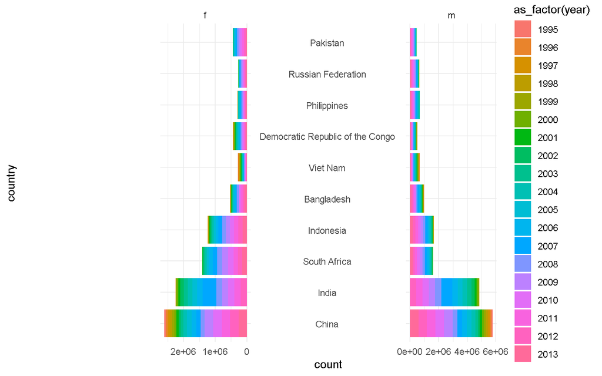

```r
who_tidy%>%
  filter(year >= 1995) %>%
  group_by(country, year, sex) %>%
  summarise(count = sum(value)) %>%
  ungroup() %>%
  group_by(country) %>%
  mutate(total = sum(count),
         prop = (count / total)*100) %>%
  ungroup() %>%
  filter(between(total, quantile(total, 0.95), quantile(total, 1))) %>%
  mutate(country = fct_rev(fct_reorder(country, total))) %>%
  mutate(count = ifelse(sex == "f", count* -1, count)) %>%
  mutate(prop = ifelse(sex == "f", prop* -1, prop)) %>%
  ggplot(aes(country, count, fill = as_factor(year))) +
  geom_col() +
  ggpol::facet_share(~sex, reverse_num = TRUE, scales = "free") +
  coord_flip() +
  theme_minimal()
```

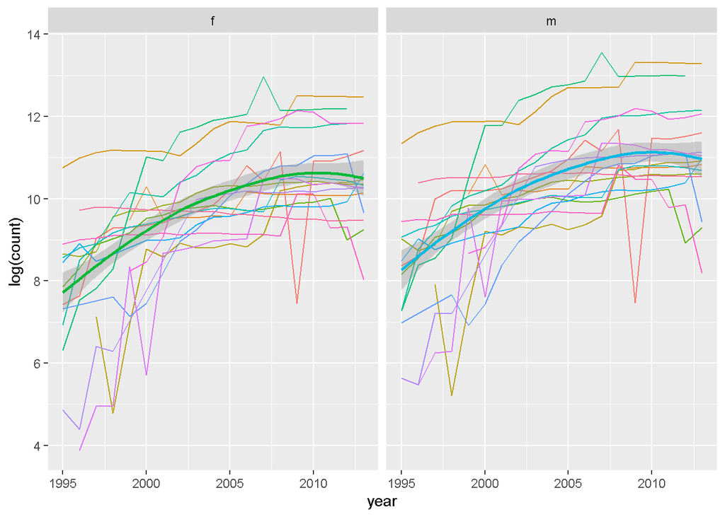

```r
who_tidy%>%
  filter(year >= 1995) %>%
  group_by(country, year, sex) %>%
  summarise(count = sum(value)) %>%
  ungroup() %>%
  group_by(country) %>%
  mutate(total = sum(count)) %>%
  ungroup() %>%
  filter(total > 500000) %>%
  ggplot(aes(year, log(count), color = country)) +
  geom_line(show.legend = FALSE) +
  geom_smooth(aes(color = sex), show.legend = FALSE) +
  facet_grid(~sex)
```

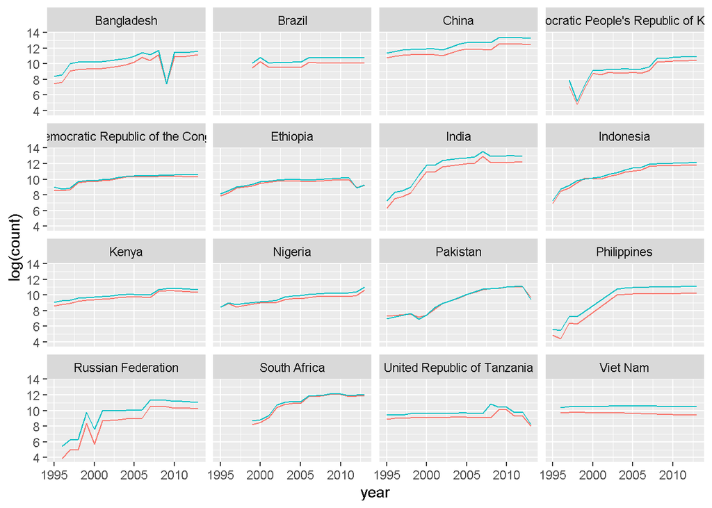

```r
who_tidy%>%
  filter(year >= 1995) %>%
  group_by(country, year, sex) %>%
  summarise(count = sum(value)) %>%
  ungroup() %>%
  group_by(country) %>%
  mutate(total = sum(count)) %>%
  ungroup() %>%
  filter(total > 500000) %>%
  ggplot(aes(year, log(count), color = sex)) +
  geom_line(show.legend = FALSE) +
  facet_wrap(~country)
```